# Practical Machine learning Course Project

Anusha Koganti

June 18, 2015

## Background

Using devices such as Jawbone Up, Nike FuelBand, and Fitbit it is now possible to collect a large amount of data about personal activity relatively inexpensively. These type of devices are part of the quantified self movement – a group of enthusiasts who take measurements about themselves regularly to improve their health, to find patterns in their behavior, or because they are tech geeks. One thing that people regularly do is quantify how much of a particular activity they do, but they rarely quantify how well they do it. In this project, goal will be to use the data from accelerometers on the belt, forearm, arm, and dumbell of 6 participants. They were asked to perform barbell lifts correctly and incorrectly in 5 different ways. More information is available from the website here: http://groupware.les.inf.puc-rio.br/har (see the section on the Weight Lifting Exercise Dataset).

### Data

The training data for this project are available here:

https://d396qusza40orc.cloudfront.net/predmachlearn/pml-training.csv

The test data are available here:

https://d396qusza40orc.cloudfront.net/predmachlearn/pml-testing.csv

The data for this project come from this source: http://groupware.les.inf.puc-rio.br/har.

### Project Submission

The goal of the project is to predict the manner in which they did the excercise. This is the “classe” variable in the training set. A report created based on how the model was built, use of cross validation, choices taken, etc. Also have to use predication model to predict 20 different test cases.

1. Submit the githhub link with R markdown and compiled HTML file describing the analysis.
2. Also apply machine learning algorithm to the 20 test cases available in the test data above.

### Code and Results

Installing packages, loading the libraries and setting the seed for reproduceability:

```r
library(caret)
library(randomForest)
```

```r
library(rpart)
library(rpart.plot)
```

```r
set.seed(1234)
```

#### Loading the datasets and preliminary cleaning

```r
trainingset <- read.csv("pml-training.csv", na.strings=c("NA","#DIV/0!", ""))
testingset <- read.csv("pml-testing.csv", na.strings=c("NA","#DIV/0!", ""))
dim(trainingset)
```

```
##[1] 19622   160
```

```r
dim(testingset)
```

```
##[1] 20 160
```

```r
trainingset<-trainingset[,colSums(is.na(trainingset)) == 0]
testingset <-testingset[,colSums(is.na(testingset)) == 0]
trainingset   <-trainingset[,-c(1:7)]
testingset <-testingset[,-c(1:7)]
dim(trainingset)
```

```
##[1] 19622   53
```

```r
dim(testingset)
```

```
##[1]20 53
```

```r
head(training set)
```

```
##roll_belt pitch_belt yaw_belt total_accel_belt gyros_belt_x
1      1.41       8.07    -94.4                3         0.00
2      1.41       8.07    -94.4                3         0.02
3      1.42       8.07    -94.4                3         0.00
4      1.48       8.05    -94.4                3         0.02
5      1.48       8.07    -94.4                3         0.02
6      1.45       8.06    -94.4                3         0.02
  gyros_belt_y gyros_belt_z accel_belt_x accel_belt_y accel_belt_z
1         0.00        -0.02          -21            4           22
2         0.00        -0.02          -22            4           22
3         0.00        -0.02          -20            5           23
4         0.00        -0.03          -22            3           21
5         0.02        -0.02          -21            2           24
6         0.00        -0.02          -21            4           21
  magnet_belt_x magnet_belt_y magnet_belt_z roll_arm pitch_arm yaw_arm
```

[output cut: 69 more lines]

```r
head(testingset)
```

```
##roll_belt pitch_belt yaw_belt total_accel_belt gyros_belt_x
1    123.00      27.00    -4.75               20        -0.50
2      1.02       4.87   -88.90                4        -0.06
3      0.87       1.82   -88.50                5         0.05
4    125.00     -41.60   162.00               17         0.11
5      1.35       3.33   -88.60                3         0.03
6     -5.92       1.59   -87.70                4         0.10
  gyros_belt_y gyros_belt_z accel_belt_x accel_belt_y accel_belt_z
1        -0.02        -0.46          -38           69         -179
2        -0.02        -0.07          -13           11           39
3         0.02         0.03            1           -1           49
4         0.11        -0.16           46           45         -156
5         0.02         0.00           -8            4           27
6         0.05        -0.13          -11          -16           38
  magnet_belt_x magnet_belt_y magnet_belt_z roll_arm pitch_arm yaw_arm
```

[output cut: 69 more lines]

```r
subsamples <- createDataPartition(y=trainingset$classe, p=0.75, list=FALSE)
subTraining <- trainingset[subsamples, ]
subTesting <- trainingset[-subsamples, ]
dim(subTraining)
```

```
##[1] 14718    53
```

```r
dim(subTesting)
```

```
##[1] 4904   53
```

```r
head(subTraining)
```

```
##roll_belt pitch_belt yaw_belt total_accel_belt gyros_belt_x
2      1.41       8.07    -94.4                3         0.02
3      1.42       8.07    -94.4                3         0.00
4      1.48       8.05    -94.4                3         0.02
5      1.48       8.07    -94.4                3         0.02
6      1.45       8.06    -94.4                3         0.02
7      1.42       8.09    -94.4                3         0.02
  gyros_belt_y gyros_belt_z accel_belt_x accel_belt_y accel_belt_z
2         0.00        -0.02          -22            4           22
3         0.00        -0.02          -20            5           23
4         0.00        -0.03          -22            3           21
5         0.02        -0.02          -21            2           24
6         0.00        -0.02          -21            4           21
7         0.00        -0.02          -22            3           21
  magnet_belt_x magnet_belt_y magnet_belt_z roll_arm pitch_arm yaw_arm
```

[output cut: 69 more lines]

```r
head(subTesting)
```

```
##  roll_belt pitch_belt yaw_belt total_accel_belt gyros_belt_x
1       1.41       8.07    -94.4                3         0.00
21      1.60       8.10    -94.4                3         0.02
22      1.57       8.09    -94.4                3         0.02
23      1.56       8.10    -94.3                3         0.02
25      1.53       8.11    -94.4                3         0.03
26      1.55       8.09    -94.4                3         0.02
   gyros_belt_y gyros_belt_z accel_belt_x accel_belt_y accel_belt_z
1          0.00        -0.02          -21            4           22
21         0.00        -0.02          -20            1           20
22         0.02        -0.02          -21            3           21
23         0.00        -0.02          -21            4           21
25         0.00         0.00          -19            4           21
26         0.00         0.00          -21            3           22
   magnet_belt_x magnet_belt_y magnet_belt_z roll_arm pitch_arm yaw_arm
```

[output cut: 69 more lines]

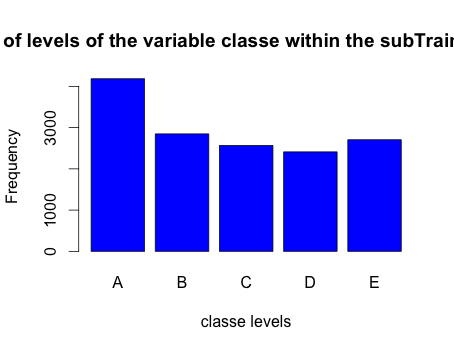

```r
plot(subTraining$classe, col="blue", main="Bar Plot of levels of the variable classe within the subTraining data set", xlab="classe levels", ylab="Frequency")
```

From the graph above, we can see that each level frequency is within the same order of magnitude of each other. Level A is the most frequent with more than 4000 occurrences while level D is the least frequent with about 2500 occurrences.

#### Decision Tree

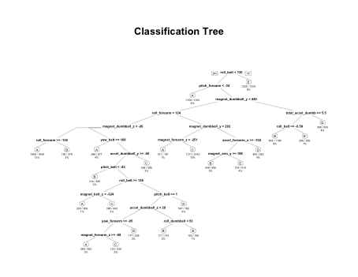

```r
model1 <- rpart(classe ~ ., data=subTraining, method="class")
prediction1 <- predict(model1, subTesting, type = "class")
rpart.plot(model1, main="Classification Tree", extra=102, under=TRUE, faclen=0)
```

```r
confusionMatrix(prediction1, subTesting$classe)
```

```
##Confusion Matrix and Statistics

          Reference
Prediction    A    B    C    D    E
         A 1235  157   16   50   20
         B   55  568   73   80  102
         C   44  125  690  118  116
         D   41   64   50  508   38
         E   20   35   26   48  625

Overall Statistics

               Accuracy : 0.7394
                 95% CI : (0.7269, 0.7516)
    No Information Rate : 0.2845
    P-Value [Acc > NIR] : < 2.2e-16

                  Kappa : 0.6697
 Mcnemar's Test P-Value : < 2.2e-16

Statistics by Class:

                     Class: A Class: B Class: C Class: D Class: E
Sensitivity            0.8853   0.5985   0.8070   0.6318   0.6937
Specificity            0.9307   0.9216   0.9005   0.9529   0.9678
Pos Pred Value         0.8356   0.6469   0.6313   0.7247   0.8289
Neg Pred Value         0.9533   0.9054   0.9567   0.9296   0.9335
Prevalence             0.2845   0.1935   0.1743   0.1639   0.1837
Detection Rate         0.2518   0.1158   0.1407   0.1036   0.1274
Detection Prevalence   0.3014   0.1790   0.2229   0.1429   0.1538
Balanced Accuracy      0.9080   0.7601   0.8537   0.7924   0.8307
```

#### Using Random Forest

```r
model2 <- randomForest(classe ~. , data=subTraining, method="class")
prediction2 <- predict(model2, subTesting, type = "class")
confusionMatrix(prediction2, subTesting$classe)
```

```
##Confusion Matrix and Statistics

          Reference
Prediction    A    B    C    D    E
         A 1394    3    0    0    0
         B    1  944   10    0    0
         C    0    2  843    6    0
         D    0    0    2  798    0
         E    0    0    0    0  901

Overall Statistics

               Accuracy : 0.9951
                 95% CI : (0.9927, 0.9969)
    No Information Rate : 0.2845
    P-Value [Acc > NIR] : < 2.2e-16

                  Kappa : 0.9938
 Mcnemar's Test P-Value : NA

Statistics by Class:

                     Class: A Class: B Class: C Class: D Class: E
Sensitivity            0.9993   0.9947   0.9860   0.9925   1.0000
Specificity            0.9991   0.9972   0.9980   0.9995   1.0000
Pos Pred Value         0.9979   0.9885   0.9906   0.9975   1.0000
Neg Pred Value         0.9997   0.9987   0.9970   0.9985   1.0000
Prevalence             0.2845   0.1935   0.1743   0.1639   0.1837
Detection Rate         0.2843   0.1925   0.1719   0.1627   0.1837
Detection Prevalence   0.2849   0.1947   0.1735   0.1631   0.1837
Balanced Accuracy      0.9992   0.9960   0.9920   0.9960   1.0000
```

### Submission

```r
predictfinal <- predict(model2, testingset, type="class")
predictfinal
```

```
## 1  2  3  4  5  6  7  8  9 10 11 12 13 14 15 16 17 18 19 20
##B  A  B  A  A  E  D  B  A  A  B  C  B  A  E  E  A  B  B  B
##Levels: A B C D E
```

```r
pml_write_files = function(x){
  n = length(x)
  for(i in 1:n){
    filename = paste0("problem_id_",i,".txt")
    write.table(x[i],file=filename,quote=FALSE,row.names=FALSE,col.names=FALSE)
  }
}

pml_write_files(predictfinal)
```